# netl_cyclone_project_feedback

## CMPINF 2100 - Final project feedback

### NETL: Cyclone optimization

This report provides general feedback from the proposals about the final project. In addition to addressing pitfalls, multiple recommendations are provided to help with performing the analysis for the project.

## Import modules

```python
import numpy as np
import pandas as pd
import matplotlib.pyplot as plt

import seaborn as sns
```

## Read data

```python
df = pd.read_csv('cyclone_model_runs.csv')

df.info()
```

```
<class 'pandas.core.frame.DataFrame'>
RangeIndex: 96 entries, 0 to 95
Data columns (total 8 columns):
 #   Column    Non-Null Count  Dtype
---  ------    --------------  -----
 0   model     96 non-null     int64
 1   r_barrel  96 non-null     float64
 2   r_vortex  96 non-null     float64
 3   h_vortex  96 non-null     float64
 4   w_inlet   96 non-null     float64
 5   h_inlet   96 non-null     float64
 6   mass      96 non-null     float64
 7   pressure  96 non-null     float64
dtypes: float64(7), int64(1)
memory usage: 6.1 KB
```

## Comments

### The `model` column

The `model` column is an identifier. It is equivalent to a row index and so it should **not** be included in clustering or predictive models. The hint to show that this variable is an indentifier is to look at the number of unique values. As shown below, there are 96 unique values. However, all but `mass` has 96 unique values!

```python
df.nunique()
```

```
model       96
r_barrel    96
r_vortex    96
h_vortex    96
w_inlet     96
h_inlet     96
mass        93
pressure    96
dtype: int64
```

The next clue is to look at the values of the variables. Let's check the head of the dataframe.

```python
df.head()
```

|  | model | r_barrel | r_vortex | h_vortex | w_inlet | h_inlet | mass | pressure |
| --- | --- | --- | --- | --- | --- | --- | --- | --- |
| 0 | 0 | 0.048788 | 0.016332 | 0.488762 | 0.024070 | 0.033515 | 1.380000e-07 | 501.974992 |
| 1 | 1 | 0.096334 | 0.020365 | 0.159614 | 0.015141 | 0.104559 | 8.760000e-09 | 146.196273 |
| 2 | 2 | 0.090460 | 0.017242 | 0.291591 | 0.021926 | 0.099530 | 1.490000e-08 | 331.987893 |
| 3 | 3 | 0.056491 | 0.018904 | 0.477338 | 0.031541 | 0.074240 | 1.760000e-07 | 242.735246 |
| 4 | 4 | 0.091406 | 0.026318 | 0.347686 | 0.017700 | 0.027279 | 3.320000e-08 | -133.910376 |

Next, let's look at the tail.

```python
df.tail()
```

|  | model | r_barrel | r_vortex | h_vortex | w_inlet | h_inlet | mass | pressure |
| --- | --- | --- | --- | --- | --- | --- | --- | --- |
| 91 | 95 | 0.072886 | 0.016492 | 0.362928 | 0.018831 | 0.102983 | 3.230000e-08 | 389.083426 |
| 92 | 96 | 0.087457 | 0.015326 | 0.336166 | 0.020464 | 0.054715 | 1.420000e-08 | 516.639008 |
| 93 | 97 | 0.099947 | 0.018064 | 0.145804 | 0.028598 | 0.056639 | 3.330000e-08 | 276.175517 |
| 94 | 98 | 0.073509 | 0.028969 | 0.155019 | 0.036327 | 0.035432 | 5.080000e-08 | 27.915392 |
| 95 | 99 | 0.086158 | 0.020691 | 0.435270 | 0.025250 | 0.022737 | 2.410000e-08 | 125.521000 |

The `model` column is an integer (as shown by the dtype) and we see that it sequentially increments from 0 up to 99. The final value therefore does not perfectly line up with the `df.index` attribute. Let's plot `model` with Pandas, which by default shows the value with respect to the index. As we see below, `model` sequentially increases as the index increases. We see a few step changes which illustrates the `model` number "skips" a value in the `df.index`. Just why it "skips" we do not know, perhaps those simulations had errors and did not complete.

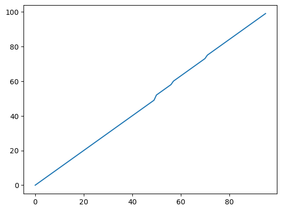

```python
fig, ax = plt.subplots()

df.model.plot(ax=ax)

plt.show()
```

### output distributions

This project is unique compared to the others in that there are **2** outputs. Everyone working on this project must therefore fit models to predict two different responses. Everyone correctly visualized the output distributions in the proposal, but let's focus on those variables here. The cell below selects the two outputs, then reshapes the dataframe into long format via `.melt()`. Histograms are used to visualize the distributions of the outputs within separate facets below.

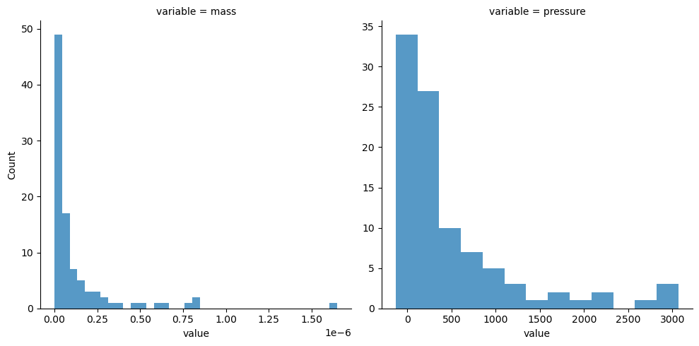

```python
sns.displot(data = df.loc[:, ['mass', 'pressure']].reset_index().rename(columns={'index': 'rowid'}).copy().melt(id_vars='rowid'),
            x='value', col='variable', kind='hist',
            facet_kws={'sharex': False, 'sharey': False},
            common_bins = False)

plt.show()
```

As we see above the two distributions are **NOT** symmetric. Lack of symmetry or *asymmetry* is referred to as **skew**. A Gaussian distribution is symmetric. The long tails to the right side (higher values) in both distributions have less frequent values at very high values compared to the most probable values (represented by the histogram bin with the highest counts).

When we see that distributions have long tails, we need to consider if there is a natural bound associated with the variable. The `.describe()` method is used to print the summary statistics for both outputs below. The distribution on `mass` appears to be "pushed up" against zero. The `.describe()` method shows the minimum value is very small, $\approx 10^{-10}$, but is above zero.

```python
df.loc[:, ['mass', 'pressure']].describe()
```

|  | mass | pressure |
| --- | --- | --- |
| count | 9.600000e+01 | 96.000000 |
| mean | 1.276272e-07 | 510.555630 |
| std | 2.380372e-07 | 707.555137 |
| min | 3.600000e-10 | -133.910376 |
| 25% | 1.167500e-08 | 83.481705 |
| 50% | 4.045000e-08 | 202.608531 |
| 75% | 1.145000e-07 | 671.496926 |
| max | 1.650000e-06 | 3068.300988 |

The distribution for `pressure` and its summary show there are negative values for `pressure`. Let's check the proportion of observations with negative `pressure` values.

```python
np.mean( df.pressure < 0 )
```

```
0.010416666666666666
```

As shown above, there is just 1% of the observations with negative `pressure` values! We see there is just a single row that meets this condition.

```python
df.loc[ df.pressure < 0, :]
```

|  | model | r_barrel | r_vortex | h_vortex | w_inlet | h_inlet | mass | pressure |
| --- | --- | --- | --- | --- | --- | --- | --- | --- |
| 4 | 4 | 0.091406 | 0.026318 | 0.347686 | 0.0177 | 0.027279 | 3.320000e-08 | -133.910376 |

This seems to go against what we saw with the histogram visualization since the lowest histogram bin has over 30 observations. However, histograms LUMP multiple observations into each BIN. We do not know where the observations are located WITHIN the bin. Including rug marks with the histogram shows the EXACT values. The faceted histogram is repeated below with the rug marks included. The rugs show there are observations of `pressure` are close to 0 within the left most bin. A rug mark is also located at the lower bound of the left most bin for `pressure`. The MINIMUM `pressure` value in therefore located less than zero!

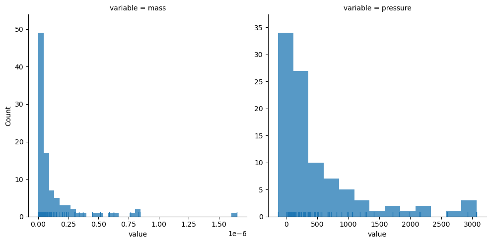

```python
sns.displot(data = df.loc[:, ['mass', 'pressure']].reset_index().rename(columns={'index': 'rowid'}).copy().melt(id_vars='rowid'),
            x='value', col='variable', kind='hist',
            facet_kws={'sharex': False, 'sharey': False},
            common_bins = False, rug=True)

plt.show()
```

Let's display the raw data to show the negative `pressure` value. The data set is filtered below to identify all rows with `pressure` less than 50. The returned rows are sorted by `pressure` in ascending order. The minimum value is NEGATIVE close to -134. The second smallest value is POSITIVE at roughly 1.5. Thus, there is "big" gap between the minimum NEGATIVE `pressure` value and the NEXT highest value!

```python
df.loc[ df.pressure < 50, : ].sort_values('pressure')
```

|  | model | r_barrel | r_vortex | h_vortex | w_inlet | h_inlet | mass | pressure |
| --- | --- | --- | --- | --- | --- | --- | --- | --- |
| 4 | 4 | 0.091406 | 0.026318 | 0.347686 | 0.017700 | 0.027279 | 3.320000e-08 | -133.910376 |
| 21 | 21 | 0.058953 | 0.025867 | 0.244263 | 0.033076 | 0.023512 | 7.190000e-09 | 1.502555 |
| 71 | 75 | 0.094048 | 0.027407 | 0.257667 | 0.022600 | 0.041676 | 8.760000e-09 | 13.266841 |
| 94 | 98 | 0.073509 | 0.028969 | 0.155019 | 0.036327 | 0.035432 | 5.080000e-08 | 27.915392 |
| 12 | 12 | 0.089345 | 0.029963 | 0.462634 | 0.026055 | 0.065747 | 3.020000e-07 | 30.313897 |
| 39 | 39 | 0.096777 | 0.028744 | 0.416502 | 0.019257 | 0.078066 | 6.480000e-08 | 35.992904 |
| 20 | 20 | 0.092015 | 0.029254 | 0.492081 | 0.038442 | 0.048033 | 8.460000e-07 | 36.201825 |
| 63 | 66 | 0.056925 | 0.029664 | 0.270647 | 0.016427 | 0.106525 | 1.530000e-07 | 37.787753 |
| 69 | 72 | 0.084980 | 0.029564 | 0.371665 | 0.030843 | 0.093570 | 8.780000e-08 | 38.173462 |
| 36 | 36 | 0.079567 | 0.027906 | 0.229486 | 0.029183 | 0.053556 | 2.070000e-08 | 40.182493 |
| 23 | 23 | 0.060861 | 0.028401 | 0.180638 | 0.023559 | 0.060407 | 1.980000e-07 | 45.483664 |
| 41 | 41 | 0.098798 | 0.028319 | 0.281464 | 0.032366 | 0.116746 | 3.830000e-09 | 48.897277 |

```python
df.sort_values(by='mass').head()
```

|  | model | r_barrel | r_vortex | h_vortex | w_inlet | h_inlet | mass | pressure |
| --- | --- | --- | --- | --- | --- | --- | --- | --- |
| 24 | 24 | 0.087015 | 0.025104 | 0.310189 | 0.035309 | 0.075721 | 3.600000e-10 | 70.624062 |
| 15 | 15 | 0.078182 | 0.013909 | 0.328403 | 0.031957 | 0.097382 | 4.800000e-10 | 891.491455 |
| 59 | 62 | 0.086422 | 0.011515 | 0.140148 | 0.019652 | 0.020213 | 8.380000e-10 | 1713.448766 |
| 51 | 53 | 0.092749 | 0.021681 | 0.110356 | 0.029436 | 0.107989 | 1.080000e-09 | 127.155553 |
| 62 | 65 | 0.069461 | 0.012973 | 0.279798 | 0.015665 | 0.057044 | 1.200000e-09 | 1068.241135 |

Why are we paying so much attention to the minimum value? When we introduced the assumptions of linear regression, we focused on the **sampling distribution** of the **output** around the AVERAGE output. Regression models assume **Gaussian** distributions for the sampling distribution. A Gaussian distribution will **not** respect such a lower bound. This means a regression model can predict a negative number, and the confidence interval and especially the prediction interval can make it seem like negative values are possible.

This means when we fit regression models for outputs with bounds we must first **transform** the output. This way the model will always respect the lower bound of the variable.

There are multiple kinds of transformations we can use to accomplish this goal. A few simple transformations are natural log, log-base 10, and the square root. I commonly use natural log. More advanced transformations are power series transformations like Box-Cox (which requires all positive numbers) or the more general Yeo-Johnson (which handles negative and positive numbers). The more advanced approaches are discussed in CMPINF 2120.

Feel free to try out different transformations to get a feel for the influence of the transformation. Let's see what the natural log transformation does by calculating the natural log of `mass` within a copied dataframe.

```python
df_copy = df.copy()

df_copy['log_mass'] = np.log( df_copy.mass )
```

As we see below, the distribution of `log_mass` is more symmetric. It is not Gaussian, but it is more Gaussian-like compared to the distribution of `mass`. The `log_mass` variable is now more appropriate to use for regression.

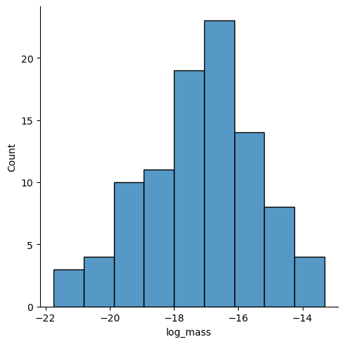

```python
sns.displot(data = df_copy, x='log_mass')

plt.show()
```

Unfortunately, we cannot apply the natural log transformation directly to `pressure`. This is because `pressure` has the negative number and the natural log function can only be applied to positive numbers! As shown below, applying `np.log()` to `df.pressure` produces a warning message! The row with the negative `pressure` value is set to MISSING!

```python
np.log( df.pressure )
```

```
C:\Users\XPS15\Anaconda3\envs\cmpinf2130\lib\site-packages\pandas\core\arraylike.py:402: RuntimeWarning: invalid value encountered in log
  result = getattr(ufunc, method)(*inputs, **kwargs)
```

```
0     6.218550
1     4.984950
2     5.805099
3     5.491971
4          NaN
        ...
91    5.963794
92    6.247344
93    5.621037
94    3.329178
95    4.832473
Name: pressure, Length: 96, dtype: float64
```

Applying the `np.log()` function therefore induces a MISSING into our data! One way to overcome this missing is to modify the transformation. Instead of applying `np.log()` as is, we can first ADD a number to "shift" the values to the right. This will cause the minimum value to greater than zero!

For example, adding 150 to `pressure` causes the minimum value to be above zero!

```python
(df_copy.pressure + 150).describe()
```

```
count      96.000000
mean      660.555630
std       707.555137
min        16.089624
25%       233.481705
50%       352.608531
75%       821.496926
max      3218.300988
Name: pressure, dtype: float64
```

We can now safely apply the `np.log()` function! No warning message is displayed and no MISSING entries are present!

```python
np.log( df_copy.pressure + 150 )
```

```
0     6.480006
1     5.691022
2     6.177919
3     5.973136
4     2.778175
        ...
91    6.289870
92    6.502249
93    6.054851
94    5.181308
95    5.618664
Name: pressure, Length: 96, dtype: float64
```

This "shift" approach seems like a hack. And in truth, it is. It is a simple way to apply overcome applying the log-transformation to negative numbers. It can be used when there is a small fraction of negative values and as we have seen, `pressure` has 1 and only 1 value less than zero. Thus, let's use this "hack" and define a new column `pressure_shift` which shifts `pressure` by 150.

```python
df_copy['pressure_shift'] = df_copy.pressure + 150
```

Let's now apply the log-transformation! However, just to show a different function lets use log base 10, `np.log10()`, instead of the natural log, `np.log()`.Feel free to try another transformation!

```python
df_copy['log_pressure'] = np.log10( df_copy.pressure_shift )
```

The distribution of the `log_pressure` variable is shown below. The distribution resembles "half" of a Gaussian. The lowest histogram bin contains a single observation which corresponds to the original negative value! The transformation is now highlighting the single negative value from the rest of the observations! Is the log base 10 transformation the best here? Perhaps not, so try out other transformations to see the effect.

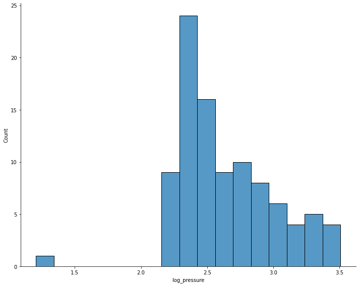

```python
sns.displot(data = df_copy, x='log_pressure')

plt.show()
```

Next, let's visualize the relationship of each output to the inputs. First, let's look at the original output. We will use Seaborn to visualize the output to input relationships with facets to denote each input. Thus, we need to reshape from wide to long format. The dataframe `lf` is created below which "gathers" the inputs into new columns named as `input_name` and `input_value`.

```python
lf = df.reset_index().\
rename(columns={'index': 'rowid'}).\
melt(id_vars=['rowid', 'model', 'mass', 'pressure'],
     value_vars=['r_barrel', 'r_vortex', 'h_vortex', 'w_inlet', 'h_inlet'],
     value_name='input_value',
     var_name='input_name',
     ignore_index=True)
```

```python
lf.info()
```

```
<class 'pandas.core.frame.DataFrame'>
RangeIndex: 480 entries, 0 to 479
Data columns (total 6 columns):
 #   Column       Non-Null Count  Dtype
---  ------       --------------  -----
 0   rowid        480 non-null    int64
 1   model        480 non-null    int64
 2   mass         480 non-null    float64
 3   pressure     480 non-null    float64
 4   input_name   480 non-null    object
 5   input_value  480 non-null    float64
dtypes: float64(3), int64(2), object(1)
memory usage: 22.6+ KB
```

It is difficult to see any clear trend between the `mass` and the inputs.

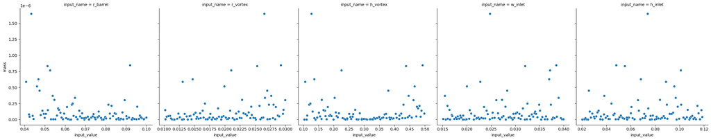

```python
sns.relplot(data = lf, x='input_value', y='mass', col='input_name',
            facet_kws={'sharex': False, 'sharey': True})

plt.show()
```

Next, visualize the scatter plot between `pressure` and each input. It's clear that `r_vortex` has a non-linear relationship with `pressure`! It seems like that is the most important relationship!

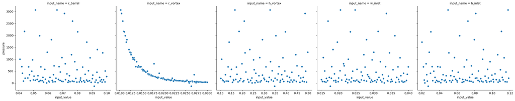

```python
sns.relplot(data = lf, x='input_value', y='pressure', col='input_name',
            facet_kws={'sharex': False, 'sharey': True})

plt.show()
```

Let's repeat this process with the log-transformed outputs.

```python
lf_copy = df_copy.drop(columns=['mass', 'pressure', 'pressure_shift']).copy().\
reset_index().\
rename(columns={'index': 'rowid'}).\
melt(id_vars=['rowid', 'model', 'log_mass', 'log_pressure'],
     value_vars=['r_barrel', 'r_vortex', 'h_vortex', 'w_inlet', 'h_inlet'],
     value_name='input_value',
     var_name='input_name',
     ignore_index=True)
```

The scatter plots between `log_mass` and the inputs are shown below. It is still difficult to see an clear relationship but the vertical axis is no longer dominated by the extreme values! The log-transformation has forced the output observations to all be on the same order of magnitude.

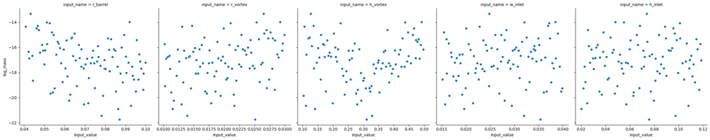

```python
sns.relplot(data = lf_copy, x='input_value', y='log_mass', col='input_name',
            facet_kws={'sharex': False, 'sharey': True})

plt.show()
```

The scatter plots between `log_pressure` and the inputs are shown below. The negative pressure now appears to be an "extreme value" away from the main "body" of the data. The `r_vortex` input still has the most clear relationship with the log-transformed pressure. Thus, the log-transformation retained the dominant input to output relationship!

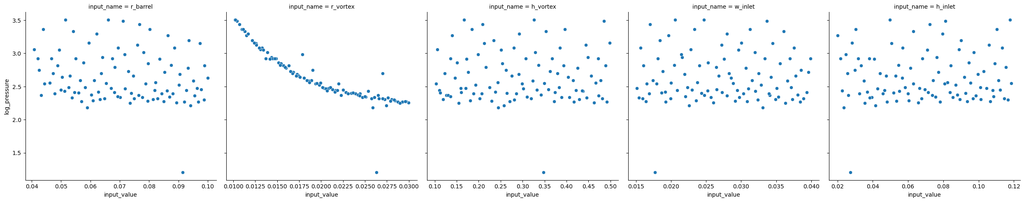

```python
sns.relplot(data = lf_copy, x='input_value', y='log_pressure', col='input_name',
            facet_kws={'sharex': False, 'sharey': True})

plt.show()
```

### Cluster analysis

Most of the proposals used all variables, inputs and outputs together in the clustering. However, there are a few alternatives to consider when trying out clustering for a multiple output regression problem like this.

The first is to cluster based just on the inputs. After examining the input distributions associated with the identified clusters, examine the **output** distributions associated with each cluster. The clusters were based just on the inputs, and so it will be interesting to see which output values are associated with each cluster.

The second is to cluster based just on the outputs. After examining the output distributions associated with the identified clusters, examine the **input** distributions associated with each cluster. The clusters were based on the outputs, and so it will be interesting to see which inputs are associated with each cluster.

The two ways of formulating the cluster analysis are complimentary to each other. However, they are both trying to help us further examine the input-to-output relationship. That said, for this particular project, clustering the output together is the **preferred** approach. The reason why will be discussed in detail later in this report.

Clustering based on the outputs should be performed with the transformed output values rather than the original outputs. Many of the original output values "pile up" near the lower bound. Transforming the outputs "stretches" them and can allow the clustering to examine the behavior more evenly across the range of the output.

To help see why the transformations are useful, a scatter plot between the original outputs is shown below. The long-tails we saw in the *marginal* distributions are represented below by the points "far" away from the main grouping around 0.

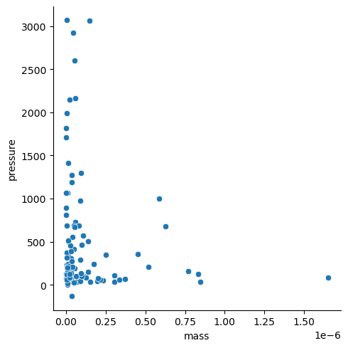

```python
sns.relplot(data = df, x='mass', y ='pressure')

plt.show()
```

The scatter plot between the log-transformed outputs is easier to look at. The markers are not piling up on one side. The observations are essentially spread out more evenly across the plot. Again, the negative pressure is highlighted as being quite different from the others!

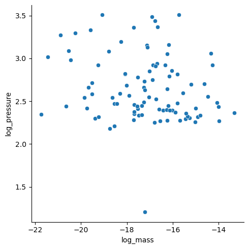

```python
sns.relplot(data = df_copy, x='log_mass', y='log_pressure')

plt.show()
```

All proposals correctly visualized the input distributions and the relationships. As you all saw the input distributions are **uniform** and there is no apparent relationship between the inputs. The pairsplot is shown below for the inputs.

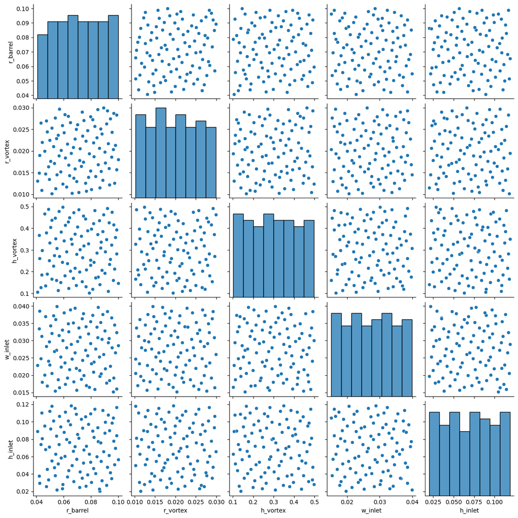

```python
sns.pairplot(data = df, vars=['r_barrel', 'r_vortex', 'h_vortex', 'w_inlet', 'h_inlet'])

plt.show()
```

The data in this project come from a **designed experiment**. The inputs were purposedly constructed to be uniformly spread across defined lower and upper bounds. The design purposedly had minimal input-to-input correlation and tried to "fill" the space as much as possible. This is why it is preferrable to cluster based on the outputs! The inputs were **designed** to have no clear structure. We therefore want to see if the output clusters can **divide** the input space into meaningful regions!

To help identify the "space filling" nature of the design, let's visualize all 5 inputs within a single graphic. No one was required to do this, but it can be useful to see.

We will visualize the relationship between `r_barrel` and `r_vortex` with a scatter plot. The three remaining inputs will be discretized based on the quartiles. The quartiles are the lines in a boxplot. Thus, the quartiles divide the variable into 4 "buckets" or bins of roughly equal number of observations.

```python
df_copy_b = df.copy()
```

```python
df_copy_b['bin_h_vortex'] = pd.qcut( df_copy_b.h_vortex, q=4)
df_copy_b['bin_w_inlet'] = pd.qcut( df_copy_b.w_inlet, q=4)
df_copy_b['bin_h_inlet'] = pd.qcut( df_copy_b.h_inlet, q=4)
```

```python
df_copy_b.info()
```

```
<class 'pandas.core.frame.DataFrame'>
RangeIndex: 96 entries, 0 to 95
Data columns (total 11 columns):
 #   Column        Non-Null Count  Dtype
---  ------        --------------  -----
 0   model         96 non-null     int64
 1   r_barrel      96 non-null     float64
 2   r_vortex      96 non-null     float64
 3   h_vortex      96 non-null     float64
 4   w_inlet       96 non-null     float64
 5   h_inlet       96 non-null     float64
 6   mass          96 non-null     float64
 7   pressure      96 non-null     float64
 8   bin_h_vortex  96 non-null     category
 9   bin_w_inlet   96 non-null     category
 10  bin_h_inlet   96 non-null     category
dtypes: category(3), float64(7), int64(1)
memory usage: 7.1 KB
```

The bar chart for `bin_h_inlet` is shown below. All 4 categories have roughly equal counts.

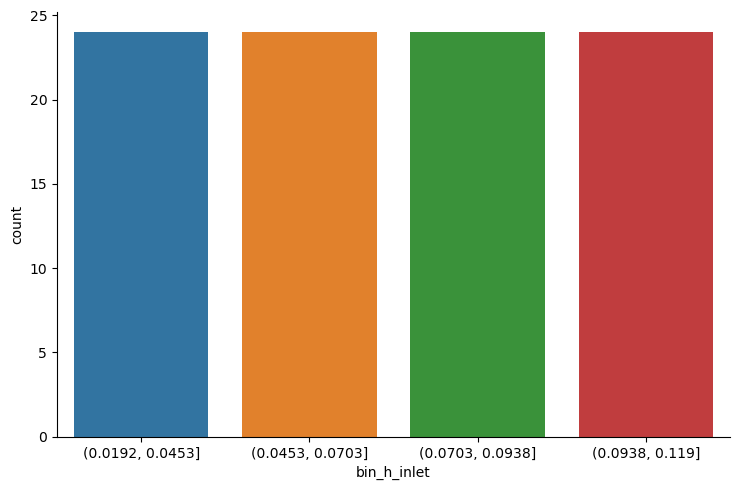

```python
sns.catplot(data = df_copy_b, x='bin_h_inlet', kind='count', aspect=1.5)

plt.show()
```

The scatter plot between `r_barrel` and `r_vortex` is shown below. The horizontal facets are controlled by the binned `h_vortex`, the vertical facets are controlled by the binned `h_inlet`, and the marker color corresponds to the binned `w_inlet`. As we can see, the two `r_` variables are typically covering their entire range in each facet and each facet has most of the 4 categorical colors present.

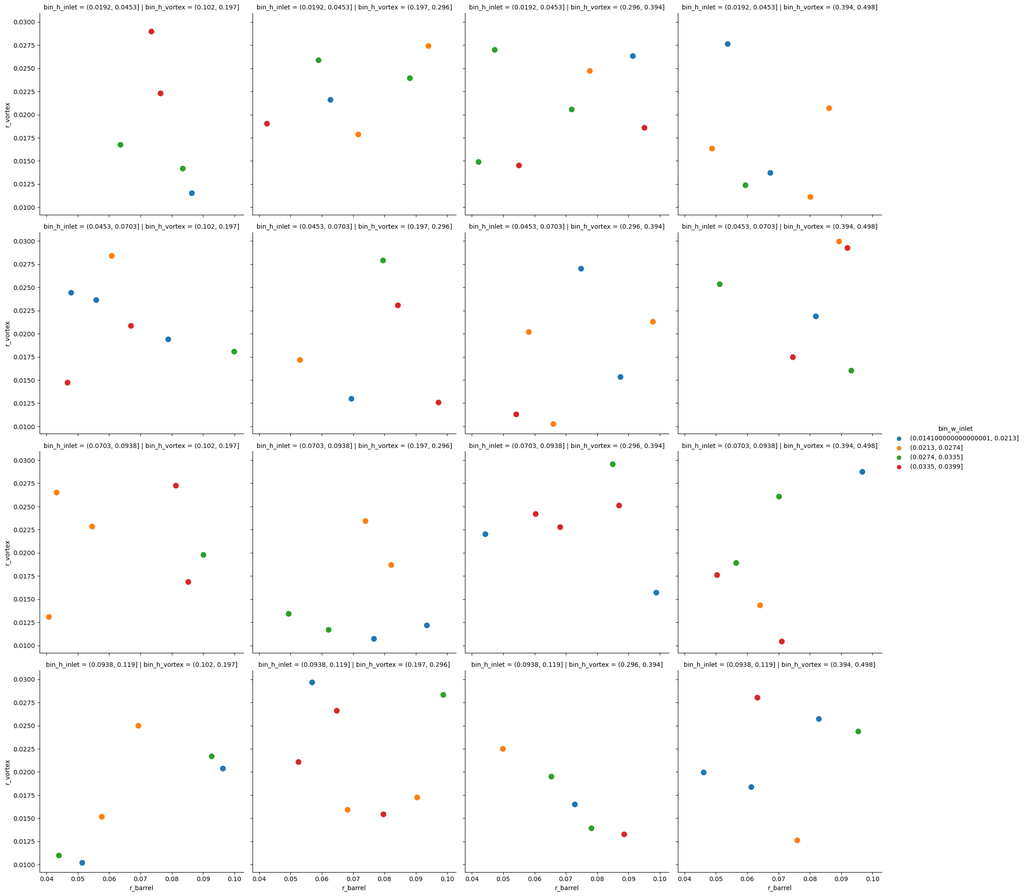

```python
sns.relplot(data = df_copy_b, x='r_barrel', y='r_vortex',
            col='bin_h_vortex', row='bin_h_inlet',
            hue='bin_w_inlet',
            s=100)

plt.show()
```

Again, no one was required to create the above visualization. You are also not required to BIN the inputs. That was done just to create the figure

### Model fitting and predictions

In the final project, you must fit multiple models of varying complexity for each output. You have seen in lecture and in the homework assignments how to create various kinds of features from the inputs including additive features, interactions, polynomials, and applying other functions to the inputs. Your task will be to identify the best performing model for each output. You must then make predictions with your selected best models to visualize the trends of the outputs with respect to the inputs. Because you are fitting the models with the transformed output, you can visualize the trends in the transformed output space. This way you can easily include the confidence interval and prediction interval around the trend. Can you identify the input values that meet the original optimization objective of the project?

This project is a regression problem. However, if you want to work on a classification problem, you can convert the `mass` variable into a binary output based on if `mass` is greater than its median value. This way you will have one regression task to predict `pressure` (via the transformed pressure) and one binary classification task to classify if the `mass` is "high" or "low". A simple way to create the binary variable is with the `np.where()` function.

```python
df_copy_b['bin_mass'] = np.where( df_copy_b.mass > df_copy_b.mass.median(), 1, 0 )
```

As shown below, we have a perfectly balanced binary outcome.

```python
df_copy_b.bin_mass.value_counts(normalize=True)
```

```
1    0.5
0    0.5
Name: bin_mass, dtype: float64
```

You are not required to work with the binary version of `mass`. This option is available if you would prefer to get practice with binary classification rather than working on 2 regression problems. If you take this approach, you must fit multiple binary classifiers, select the best one, and then predict the probability of the event. You must visualize the probability of the event with respect to the inputs to identify inputs that meet the original requirements of the optimization problem.